# Лабораторная работа №4

Операционные системы

Бекназарова Виктория Тиграновна.

Российский университет дружбы народов, Москва, Россия

01 марта 2023

## Цели и задачи

Приобретение практических навыков взаимодействия пользователя с системой по- средством командной строки.

## Содержание исследования

1. Определим полное имя нашего домашнего каталога. Далее относительно этого ката- лога будем выполняться последующие упражнения.

2. Перейдем в каталог /tmp.Выведем на экран содержимое каталога /tmp. Для этого используем команду ls с различными опциями.

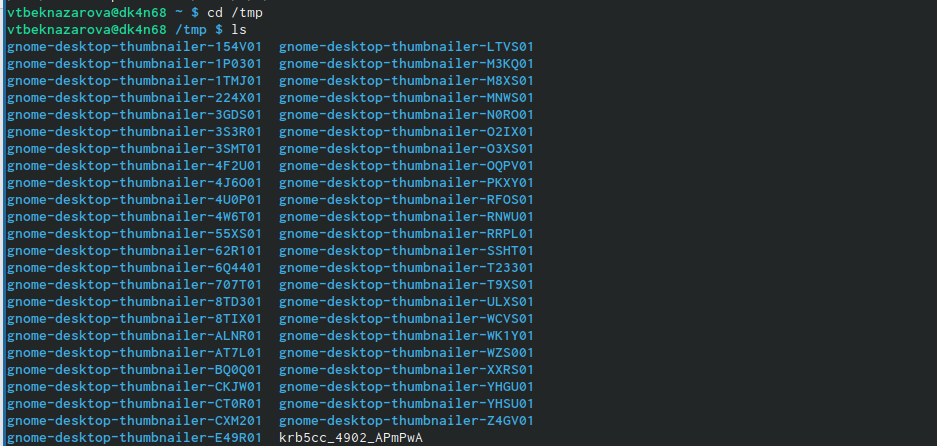

Команда ls

Мы можем увидеть содержимое каталога со скрытыми файлами при помощи опции -а

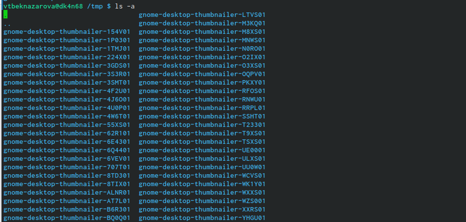

Команда ls -a

При помощи опции -l, мы можем увидеть подробное содержимое каталога.

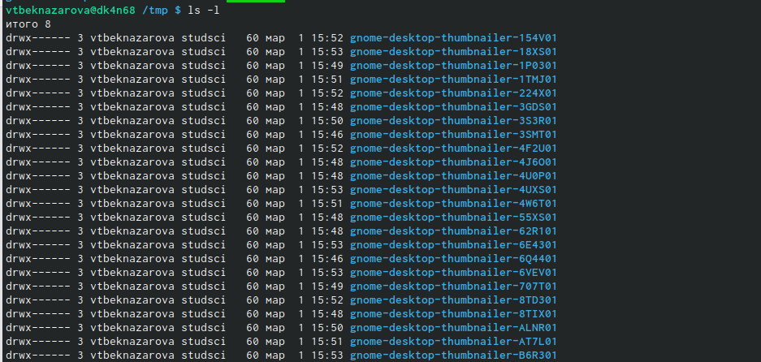

Команда ls -l

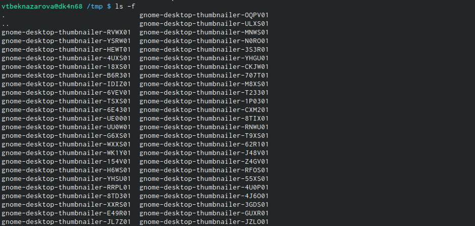

Команда ls -f

В каталоге /var/spool есть подкаталог с именем cron

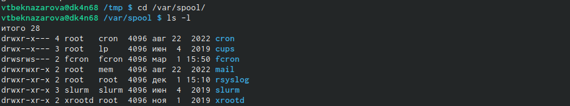

Каталог /var/spool

Перейдем в наш домашний каталог и выведем на экран его содержимое. Определили, кто является владельцем файлов и подкаталогов при помощи команды ls -al. Большинство файлов принадлежат мне и пользователю root.

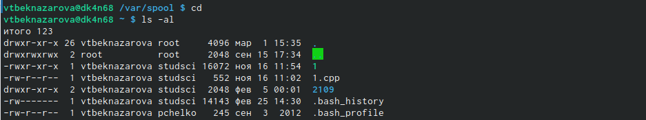

Файлы в домашнем каталоге

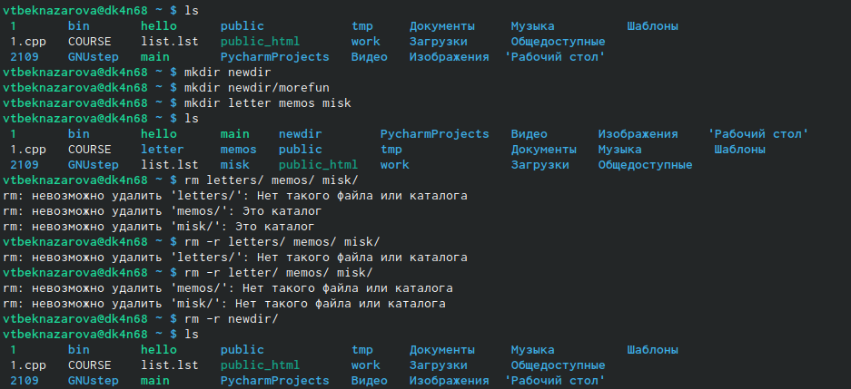

Действия с каталогами

4. С помощью команды man определим, какую опцию команды ls нужно использо- вать для просмотра содержимое не только указанного каталога, но и подкаталогов, входящих в него.Нам нужен ключ -R
5. С помощью команды man определим набор опций команды ls, позволяющий отсорти- ровать по времени последнего изменения выводимый список содержимого каталога с развёрнутым описанием файлов.

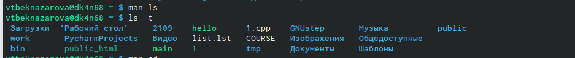

Команда ls -t

6. Используем команду man для просмотра описания следующих команд: cd, pwd, mkdir, rmdir, rm.

[figure not shown]

Терминал

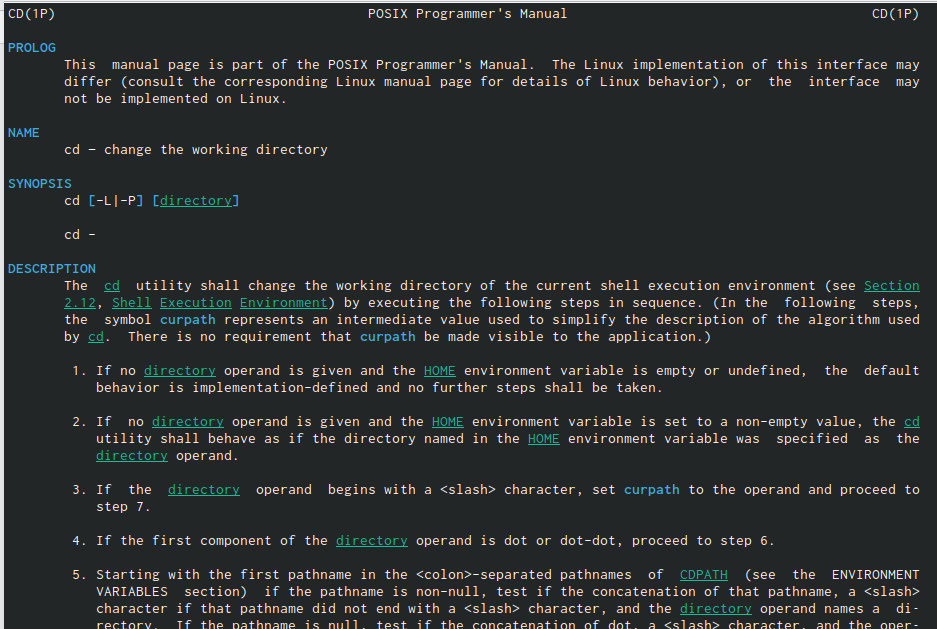

Справка по команде cd

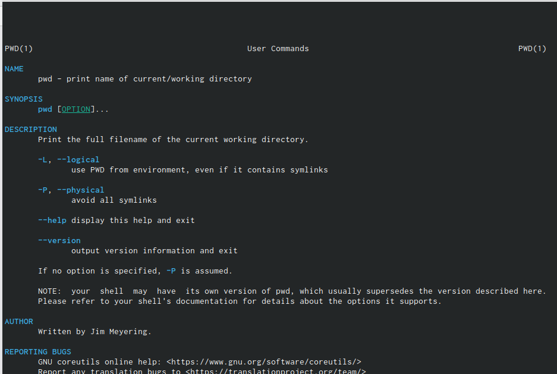

Справка по команде pwd

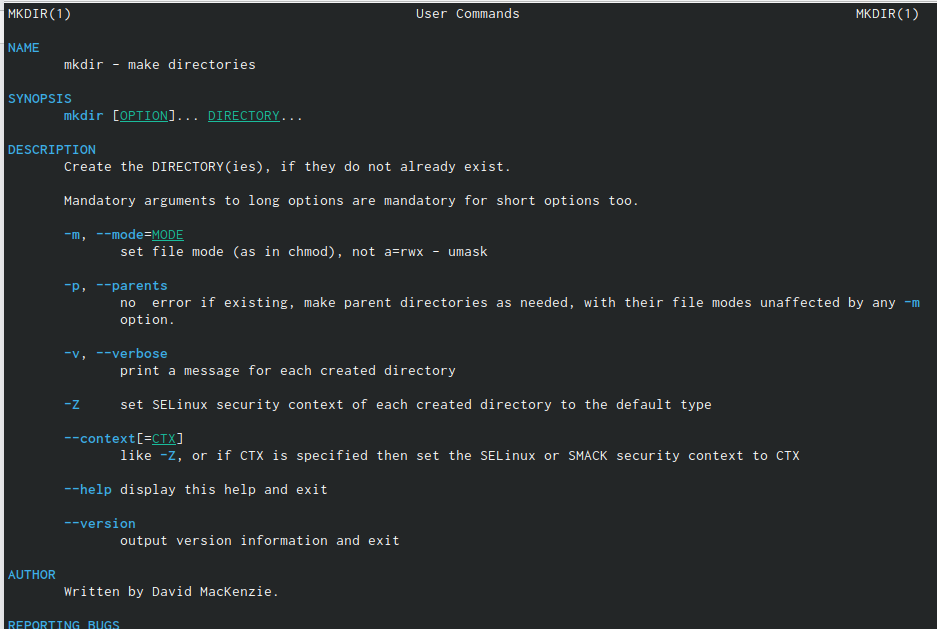

Справка по команде mkdir

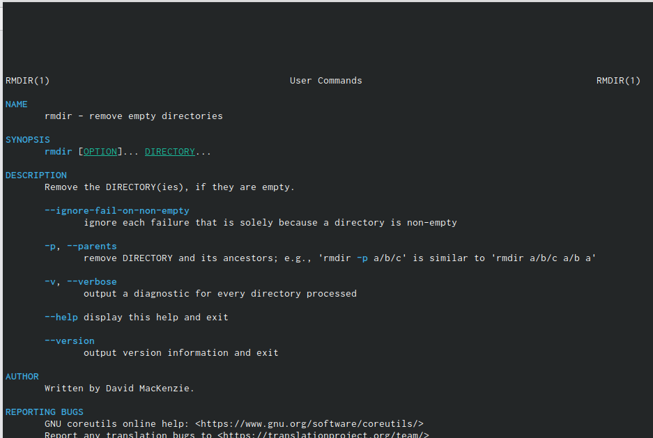

Справка по команде prmdir

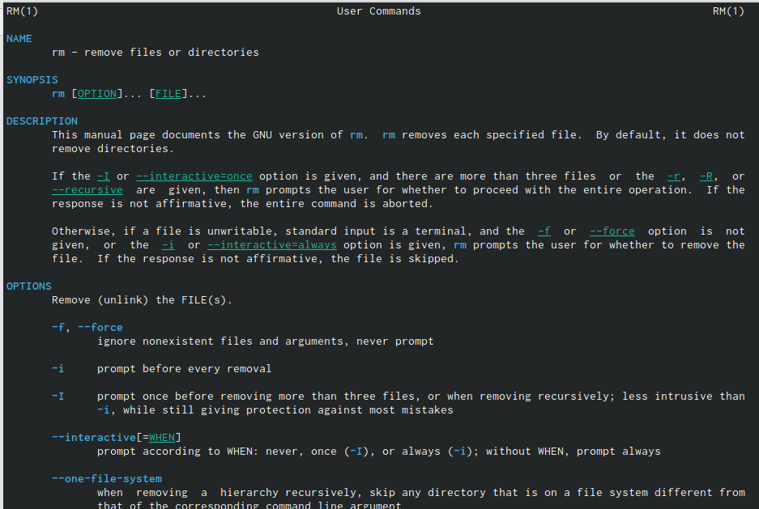

Справка по команде rm

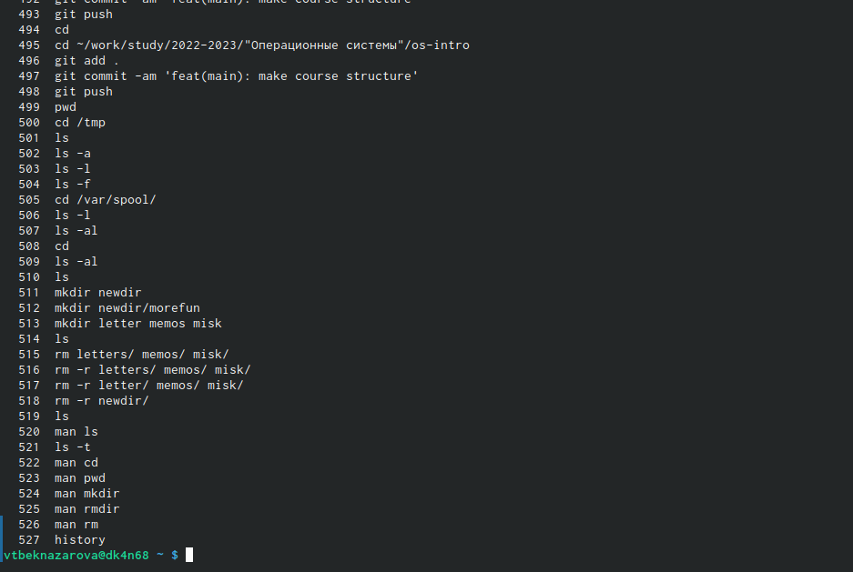

Команда history

## Результаты

Мы приобрели практические навыки взаимодействия пользователя с системой посредством командной строки.